# Der Effekt von Earnings-Conference Calls am Aktienmarkt

# Motivation

Earnings Conference Calls sind zentrale Informationsereignisse in Finanzmärkten. Hier kommuniziert das Management direkt mit Investoren und Analysten über die aktuelle Geschäftslage und Zukunftsaussichten. Die finanzwirtschaftliche Forschung zeigt, dass diese Calls erhebliche Kursbewegungen auslösen können - doch die zugrundeliegenden Mechanismen sind noch nicht vollständig verstanden.

Während traditionelle Finanztheorie von effizienten Märkten ausgeht, die alle verfügbaren Informationen sofort verarbeiten, zeigen empirische Studien, dass die Art der Kommunikation und das Sentiment der Aussagen eigenständige Erklärungskraft für Aktienkursreaktionen besitzen. Diese Erkenntnisse haben direkte praktische Relevanz: Banken nutzen Sentiment-Analysen für algorithmische Handelsstrategien, Hedge Fonds entwickeln systematische Ansätze zur Textauswertung, und Asset Manager integrieren qualitative Informationen in ihre Bewertungsmodelle.

In diesem Projekt kombinieren Sie Event Studies - eine etablierte Methode der empirischen Finanzforschung zur Messung von Informationseffekten - mit modernen Large Language Models zur systematischen Textanalyse. Sie untersuchen, ob und wie sich qualitative Aussagen des Managements in quantifizierbaren Marktreaktionen niederschlagen, und lernen dabei sowohl die methodischen Grundlagen der Kausalitätsidentifikation als auch den praktischen Umgang mit KI-gestützten Finanzanalysen kennen.

# Event-Study-Methodik und theoretische Diskussion

1. Lesen Sie das Kapitel [“Event Studies” in Huntington-Klein (2021)](https://theeffectbook.net/ch-EventStudies.html) und beantworten Sie die folgenden Fragen dazu:

Kann eine Eventstudie helfen, den kausalen Effekt eines Earnings Conference Calls auf die Aktienrendite eines Unternehmens zu identifizieren? Gehen Sie bei der Beantwortung dieser Frage insbesondere auf die nachfolgenden Punkte ein:

- Welche Art von Variation nutzt eine Eventstudie zur Identifikation des Effekts?
- Welche Voraussetzung(en) müssen erfüllt sein, damit die Eventstudie eine gültige Kausalschätzung liefert?
  - Was bedeutet das “Joint-Test Problem” in diesem Kontext?

Eine Eventstudie ist eine empirische Methode, die vor allem in der Finanzforschung angewendet wird. Untersucht wird, wie sich ein bestimmtes Ereignis auf eine Variable - z.B. auf den Aktienkurs - auswirkt. Dabei muss dieses Event zu einem bestimmten Zeitpunkt stattfinden, es gibt also einen klaren Zeitraum vor und nach dem Ereignis.

**Welche Art von Variation nutzt eine Eventstudie zur Identifikation des Effekts?**  
Eine Eventstudie nutzt zeitliche Variation rund um ein klar definiertes Ereignis, wie z.B. die Durchführung eines Earnings Conference Calls, um den Effekt dieses Ereignisses auf ein Ergebnis (z.B. die Aktienrendite) zu messen. Es wird also die Rendite direkt vor und direkt nach der ECC gemessen. Diese Methode basiert auf der Annahme, dass der Zeitpunkt des Events eine plötzliche, exogene Informationsveränderung darstellt.

**Voraussetzungen für gültige Kausalschätzung**  
Eine Eventstudie kann also helfen, den kausalen Effekt eines Earnings Conference Calls auf die Aktienrendite eines Unternehmens zu identifizieren. Allerdings müssen dafür bestimmte Bedingungen erfüllt sein, damit kausale Schätzungen möglich sind. Zum einen dürfen keine anderen Ereignisse rund um den Earnings Call stattfinden, welche die Aktienrendite beeinflussen könnten (z.B. regulatorische Änderungen, Makronachrichten, Produktankündigungen). Wenn dies der Fall wäre, wäre die beobachtete Änderung nicht eindeutig dem Earnings Call zuzuordnen. Zum anderen müssen alle entscheidenden Informationen, die zu einer Veränderung des Kurses führen könnten, ausschließlich aus dem Earnings Call stammen. Es dürfen also keine Investoren bereits vor dem Earnings Call die entsprechenden Informationen haben, da sonst das Ereignis seinen Effekt verliert. Eine weitere Annahme ist die der effizienten Märkte. Es wird davon ausgegangen, dass Märkte rasch und vollständig auf neue Informationen reagieren. Wenn dies nicht der Fall wäre, würde sich der Effekt über mehrere Tage ziehen, was die Nachvollziehbarkeit erschwert. Eine letzte Bedingung ist, dass man wissen muss, wie sich der Kurs ohne das Event entwickelt hätte, um entsprechende Unterschiede analysieren zu können. Dies wird meist auf Basis eines Marktmodells gemacht, welches allerdings gut spezifiziert sein muss.

**Das Joint-Test Problem**  
Das Joint-Test Problem ist ein zentrales methodisches Problem bei Eventstudien. Bei Eventstudien werden immer zwei Hypothesen getestet. Zum einen die Hypothese, ob das Event einen Effekt auf eine bestimmte Variable hat und zum anderen, ob das Modell zur Schätzung der normalen Renditen korrekt spezifiziert ist. Erhält man also einen Effekt, lässt sich nicht sicher sagen, ob der Effekt tatsächlich durch das Event verursacht wurde oder ob der Effekt nur auf ein schlechtes Modell zurückgeht. Beispielsweise wenn der Aktienkurs nach einem Earnings Call steigt, könnte das entweder an neuen Informationen aus dem Call liegen – oder daran, dass das Modell die erwartete Kursentwicklung falsch vorhergesagt hat.

Zusammenfassend kann man sagen, dass eine Eventstudie helfen kann, den kausalen Effekt eines Earnings Conference Calls auf die Aktienrendite zu identifizieren, allerdings nur wenn bestimmte Annahmen erfüllt sind. Jedoch selbst wenn alle Annahmen erfüllt sind kann die Interpretation der Ergebnisse durch das Joint-Test Problem erschwert werden.

# Daten und Datenaufbereitung

## Finanzmarktkennzahlen

2. Sie sollten in einem ersten Schritt Finanzkennzahlen aus Datastream herunterladen. Insbesondere sollten Sie den Return Index (RI) und die Total Assets (WC02999) für alle Firmen im Euro Stoxx 600 Technology Index ( wir haben Ihnen die RIC Kürzel in der Readme bereitgestellt ) vom 01.01.2020 bis heute extrahieren.

Bitte laden Sie für den Return Index tägliche Daten herunter und für die Total Assets Quartalsdaten. Weiterhin sollten Sie den Total Return Index (RI) des Euro Stoxx 600 (RIC = .STOXX) herunterladen (auch tägliche Daten). Bitte achten Sie darauf alle Daten **in Euro** herunterzuladen.

Achten Sie darauf die RIC als eindeutige Identifikationskennung in ihren Datensatz aufzunehmen.

Das Institut für Finanzwirtschaft der Universität Ulm hat einen ausführlichen [Guide zu Datastream](https://www.uni-ulm.de/fileadmin/website_uni_ulm/allgemein/Update_Introduction_Datastream_May_2025.pdf) erstellt, der Ihnen beim Download der Daten sicherlich helfen kann.

Die Universität Ulm stellt für den Download Remote-PCs zur Verfügung, auf die Sie sich von daheim aus einloggen können. Bitte buchen Sie sich hier einen Slot um Zugriff auf diese PCs zu erhalten: https://www.uni-ulm.de/mawi/iof/lehre/proposals-for-theses/datastream-and-workspace/

Sie sollten ihre Daten in Excel herunterladen und in ihrem Projekt im Unterordner `data` abspeichern.

*Hinweis 1:* Es empfiehlt sich zwei Tabellenblätter im Excel File anzulegen, eines für die täglichen Daten und eines für die Quartalsdaten

*Hinweis 2:* Datastream ist eine Datenbank, die Kennzahlen zur Finanzlage von börsennotierten Unternehmen weltweit beinhaltet. Die Lizenzen zu Datastream an der Universität Ulm werden von der Studienkommission Wirtschaftswissenschaften und der LBBW bezahlt und die Datenbank steht allen WiWi-Studierenden frei zur Verfügung. [Nähere Informationen zu Datastream finden Sie hier](https://www.uni-ulm.de/mawi/iof/lehre/proposals-for-theses/datastream-and-workspace/) (Bitte beachten: Sie müssen im Uninetz (z.B. über VPN) eingeloggt sein um die Informationen zu sehen und um sich auf die Remote-PCs loggen zu können).

*Hinweis 3:* Bei den Total Assets müssen Sie immer das Enddatum des vorherigen Jahres nehmen für den Download, d.h. Start Date wäre 31.12.2019

3. Lesen Sie die Excel Datei, welche Sie in Aufgabe 2 erstellt haben, in R ein. Achten Sie darauf, dass diese Daten tidy und richtig formatiert sind. Joinen Sie die täglichen Daten mit den Quartalsdaten für die relevanten Firmen. Die Quartalsdaten zählen für das komplette Quartal zu dem diese hinzugemerged wurden.

Setzen Sie sich mit den Aktienkursen auseinander und beantworten folgende Fragen: - Sie wollen in Aufgabe 4 *Renditen* berechnen, warum sollten Sie Daten zum “Total Return Index” und nicht dem “Price” oder “Unadjusted Price” herunterladen? Schauen Sie sich zur Klärung dieser Frage den [Guide der Uni Ulm zu Datastream](https://www.uni-ulm.de/fileadmin/website_uni_ulm/allgemein/Update_Introduction_Datastream_May_2025.pdf) genauer an. Diesen Guide sollten sie auch für den Download der Daten heranziehen.

*Hinweis:* In dem tidy Datensatz sollten Sie eine Spalte mit dem Unternehmensidentifier (RIC), eine mit dem Datum und eine mit der Variablen (RI bzw. Total Assets) haben

**Warum nutzen wir den Total Return Index (RI) um Rediten zu berechnen und nicht den (unangepassten) Preis der Aktie?**  
Der Total Return Index eignet sich ideal, um die Volatilität und Performance einer Anlage zu messen. Der unangepasste Preis ist dagegen lediglich der historische Börsenpreis der Aktie. Er eignet sich lediglich dazu, Aktienkursbeschränkungen einzuführen und seine Daten zu filtern, aber nicht zur Berechnung der Rendite. Die Variable „Preis” ist der bereinigte Preis um Aktiensplits und ähnliche Kapitalmaßnahmen. Da der Preis jedoch nicht um Dividenden bereinigt ist, eignet sich die Variable nicht für die Berechnung der Renditen.

## Renditen berechnen

4. In ihrem Datastream-Datensatz, welchen Sie in Aufgabe 2 bereits eingelesen und in Aufgabe 3 bearbeitet haben, sind die *Total Return Indices* (RI) der größten Unternehmen aus der Tech-Branche in Europa enthalten, sowie der *Total Return Indix* des Euro Stoxx 600. Der Euro Stoxx 600 ist ein großer, diversifizierter Aktienindex in Europa in dem die 600 größten Unternehmen gelistet sind. Sie sollten den Euro Stoxx 600 als Benchmark ( Rendite des Marktes ) für ihre betrachteten Unternehmen verwenden. Bitte berechnen Sie in dieser Aufgabe die Tagesrenditen aller Einzelunternehmen als:

$$\begin{equation}
Rendite_{i,t} = \frac{RI_{i,t} - RI_{i,t-1}}{RI_{i,t-1}}
\end{equation}$$

mit i = {jedes Einzelunternehmen im Datensatz} und t = {Tag}

und des Euro Stoxx 600 als:

$$\begin{equation}
Rendite_{m,t} = \frac{RI_{m,t} - RI_{m,t-1}}{RI_{m,t-1}}
\end{equation}$$

mit m = {Euro Stoxx 600} und t = {Tag}

Prüfen Sie auf NA in den Anfangszeilen und entfernen Sie diese.

Speichern Sie die Renditen der jeweiligen Unternehmen in einer neuen Variable `Rendite` ab und die Rendite des Euro Stoxx 600 als `Marktrendite`.

5. In Aufgabe 1 hatten Sie sich bereits mit der Event-Study Methodik beschäftigt, welche Sie im weiteren Verlauf des Projektes anwenden sollen. Ein erster Schritt ist es, sogenannte *Abnormale Renditen* zu berechnen. Dies sollten Sie in dieser Aufgabe mit dem sogenannten Market-adjusted returns model tun. Bitte ziehen Sie dafür die Rendite des Marktindex von der Rendite des einzelnen Unternehmens pro Tag ab.

$$\begin{equation}
AbnormaleRendite_t = Rendite_{i,t} - Rendite_{m,t}
\end{equation}$$

Beantworten Sie dazu folgende Frage:

- Warum ist es nötig die Marktrendite ( $Rendite_{m,t}$ ) von der Rendite der Einzelaktien abzuziehen? Nutzen Sie ihre Erkenntnisse aus Aufgabe 1 zur Beantwortung dieser Frage.

**Warum ist es nötig die Marktrendite von der Rendite der Einzelaktien abzuziehen**  
Die Marktrendite beeinflusst alle Aktien am gleichen Tag. Um zu sehen, wie ein Ereignis wie ein Earnings Call die Aktie speziell beeinflusst, muss man diese allgemeinen Markteffekte herausrechnen. Deshalb zieht man die Marktrendite von der Einzelaktienrendite ab. So erhält man die abnormale Rendite, die nur den firmenspezifischen Effekt zeigt.  
Ohne diesen Schritt könnte man nicht sagen, ob die Renditeänderung durch das Ereignis oder durch den Markt allgemein verursacht wurde.  
Das ist wichtig, damit die Eventstudie den kausalen Effekt des Ereignisses korrekt messen kann.

## Earnings Call-Transkripte von LSEG Workspace einlesen

Die Basis für alle weiteren Analysen sind die Abnormalen Renditen der einzelner Unternehmen, die Sie in den vorherigen Aufgaben berechnet haben. Jedoch benötigen Sie nun noch ein Event, dessen Effekt Sie im Rahmen der Eventstudie analysieren möchten. Hier kommen die bereits in der Motivation erwähnten Earnings-Conference-Calls ins Spiel, die Sie im weiteren Verlauf des Projekts näher analysieren sollten. Die Earnings Conference Calls finden für große Unternehmen in der Regel quartalsweise statt. Manche Unternehmen halten jedoch auch nur halbjährliche Earnings Conference Calls ab und andere verzichten ganz darauf.

6. Wir haben Ihnen die Earnings Conference Calls aus LSEG Workspace für alle Firmen aus dem Euro Stoxx 600 Technology Sektor ab 2020 bis zum aktuellen Rand heruntergeladen und diese unter `data/transcripts.zip` bereitgestellt. Lesen Sie die Dateien in R ein. Ihr Datensatz sollte für jedes Transkript das RIC-Kürzel, Datum und den Text des Transkripts beinhalten, dies können Sie aus dem Namen der Datei extrahieren.

*Hinweis:* Das RIC Kürzel finden Sie im Namen der Datei (Beispiel: “2020-Jan-28-SAPG.DE-140242583050-Transcript.txt” -> “Datum-RIC-Nummer-Transcript.txt”)

Die Earnings Conference Calls laufen immer gleich ab: Zuerst spricht der CEO und meist CFO über die aktuellen Entwicklungen am Markt und wie das Unternehmen aktuell steht. Weiterhin werden Einschätzungen für die Zukunft angesprochen. Im zweiten Teil, der Q&A Sektion, dürfen Analysten Fragen an das Management stellen. Dieser Teil ist meist informativer als die vorbereiteten Statements des Managements, da die Fragen nicht vorher abgesprochen werden und das Management spontane Antworten bereithalten muss.

Sie sollen sich in diesem Projekt auf den zweiten Teil, d.h. die Q&A Section in den Earnings Conference Calls konzentrieren.

7. Analysieren Sie im ersten Schritt die Earnings Conference Calls indem Sie einige davon überfliegen. Schauen Sie explizit nach Hinweisen, ob und wie die Q&A Sektion im Text von den anderen Inhalten abgetrennt ist. Anschließend sollten Sie diese Q&A Sektion in den Earnings Conference Calls in R extrahieren, da Sie nur diese Sektion in den späteren Aufgaben analysieren sollen.

Da es vorteilhaft für ihre weitergehenden Analysen ist möglichst kompakte Texte ohne Redundanzen zu haben, sollten Sie zusätzlich die Definitionen und Disclaimer Sektion am Ende des Earnings Calls entfernen.

*Hinweis 1:* Der Anteil der Q&A Sektion an der Gesamtkonversation liegt in der Regel unter 80%. Für manche Earnings Conference Calls ist dieser Anteil höher, aber hier würde ich empfehlen nachzuschauen, ob Sie die Q&A Sektion richtig extrahiert haben. Manchmal gibt es keine Q&A Sektion, dann sollte dort auch kein Text extrahiert werden.

*Hinweis 2:* Nutzen Sie das Paket `stringr` um Textmanipulationen vorzunehmen. In diesem [Cheatsheet](https://rstudio.github.io/cheatsheets/strings.pdf) sehen Sie die Hauptanwendungen inkl. regulärer Ausdrücke, welche wichtig sind um mit Texten zu arbeiten.

8. Stellen Sie in einer Grafik anschaulich dar, wie viele Worte in einem typischen Earnings Conference Call verwendet werden und wie viel davon die Q&A Sektion einnimmt.

Beschreiben Sie ihre Grafik.

*Hinweis:* Eventuell wollen Sie hier die Verteilungen zeigen o.ä.? Entscheiden Sie selbst, welche Grafik Sie produzieren.

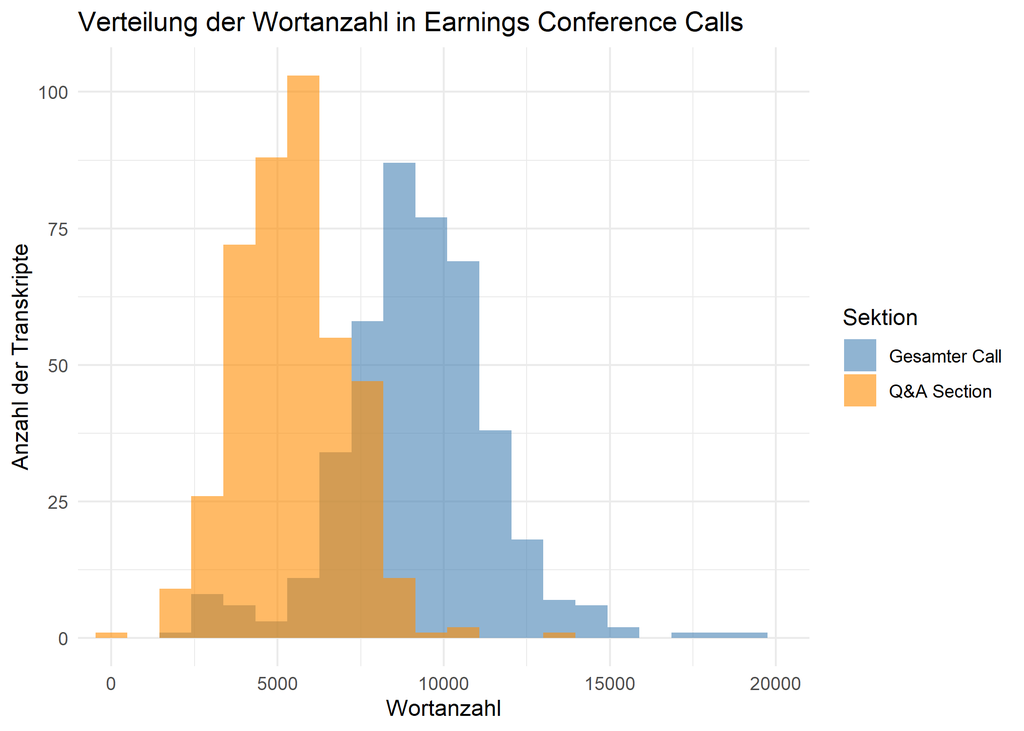

## Themenkategorien und Sentiment-Scores

Nachdem Sie nun die Earnings Conference Calls in R eingelesen und einen ersten Eindruck von deren Inhalt erhalten haben sollten Sie diese mit einem LLM (konkret mit Google Gemini) analysieren. Dafür sollten Sie einen Zero-Shot Prompt erstellen und mit Hilfe dieses Prompts die Aussage der Q&A Sektionen der Earnings Conference Calls analysieren.

9. Entwickeln Sie einen Zero-Shot Prompt für ein Large Language Model (LLM), der Earnings Conference Call Transcripts analysiert und strukturierte Sentiment-Bewertungen ausgibt. Bitte beachten Sie dabei folgende Punkte:

Zielkategorien:

- Unternehmensperformance (Finanzlage, Wachstumschancen, Unternehmensrisiken)
- Marktumfeld (Branche, Wettbewerb, externe Faktoren)

Output-Format:

- JSON-Struktur mit Sentiment-Scores von -1 (sehr negativ) bis +1 (sehr positiv)
- Keine zusätzlichen Erklärungen oder Markdown-Formatierung

Sie sollten in ihrem Prompt nach einem JSON Output verlangen (strukturiertes Format), welchen Sie mit dem Paket `jsonlite` gut in R verarbeiten können.

*Hinweis 1:* Im Anhang ist eine Erklärung für die Unterschiede zwischen einem Zero-Shot Prompt, einem One-Shot Prompt und einem Few-Shot Prompt

*Hinweis 2:* Wir haben Ihnen ein [Tutorial zusammengestellt](https://projektkurs-data-science-ulm2425.netlify.app/tutorials/zero-prompting), welches das Prompting an einem Beispiel zeigt.

“Du bist ein erfahrener Finanzanalyst, der auf die Bewertung von Unternehmenskommunikation spezialisiert ist.

Deine Aufgaben:  
- Objektive Sentiment-Analyse von Earnings-Calls  
- Bewertung der Unternehmensperformance über die Faktoren Finanzlage, Wachstumslage und Unternehmensrisiken  
- Bewertung des Marktumfeld unter Berücksichtigung der Faktoren Branche, Wettbewerb und externen Faktoren

Deine Arbeitsweise:  
- Verwende eine Skala von -1 (sehr negativ) bis +1 (sehr positiv)  
- Gebe keine zusätzlichen Erklärungen oder Markdown Formatierungen

Bitte gebe deine Antwort für den Analysierten Earnings-Call als JSON-Output ausschließlich im folgenden Format aus:

{  
Finanzlage: <numerischer Score zwischen -1 und 1>,  
Wachstumschancen: <numerischer Score zwischen -1 und 1>,  
Unternehmensrisiken: <numerischer Score zwischen -1 und 1>,  
Branche: <numerischer Score zwischen -1 und 1>,  
Wettbewerb: <numerischer Score zwischen -1 und 1>,  
Externe_Faktoren: <numerischer Score zwischen -1 und 1>  
}”

10. Im nächsten Schritt sollten Sie sich in das Paket [`ellmer`](https://ellmer.tidyverse.org/) einarbeiten. Durch `ellmer` erhalten Sie Zugriff auf alle gängigen LLMs mittels R über einen API Zugang. Wir haben ihnen für dieses Projekt ein Google Konto pro Gruppe erstellt und den API Schlüssel für jede Gruppe in das dazugehörige Repo (Readme) gepushed.
- Lesen Sie sich in das [`ellmer`](https://ellmer.tidyverse.org/) Paket ein und wie Sie den API Schlüssel für Google Gemini in ihrer .Renviron Datei hinterlegen können
- Untersuchen Sie die unterschiedlichen Modelle, die Google zur Verfügung stellt und deren Ratelimits: https://ai.google.dev/gemini-api/docs/models?hl=de

Bitte beantworten Sie folgende Fragen:

- Was sind die Vorteile/Nachteile der einzelnen Google Modelle?
- Welches (kostenlose) Modell würden Sie für ihre aktuellen Analysen bevorzugt einsetzen? Begründen Sie!
- Welche Möglichkeiten haben Sie, nicht in die Ratelimits zu kommen?
- In `ellmer` können Sie mittels dem [`params()`](https://www.tidyverse.org/blog/2025/05/ellmer-0-2-0/#parameters) Parameter auch die Temperatur ihres Modells einstellen. Was ist mit der Temperatur gemeint und was sind die Vorteile/Nachteile einer niedrigen Temperatur?

**Was sind die Vorteile/Nachteile der einzelnen Google Modelle?**  
Google bietet mit Gemini die drei wesentlichen Modelle “2.5 Pro”, “2.5 Flash” und “2.5 Flash-Lite” an. Hierbei unterstützen alle Modelle die Eingabeformate Audio, Bilder, Videos und Text, wobei das Modell “2.5 Pro” zusätzlich das Format “PDF” unterstützt. Alle Modelle geben Text als Ausgabeformat zurück. Die Modelle “2.5 Pro” und “2.5 Flash” unterstützen jeweils ein Eingabetoken-Limit von 1.048.676 und ein Ausgabetoken-Limit von 65.536, während das Modell “2.5 Flash-Lite” ein Limit von 1.000.000 Eingabetoken und 64.000 Ausgabetoken hat. Alle Modelle unterstützen Funktionen wie strukturierte Ausgabe, Caching, Funktionsaufrufe, Codeausführung, „Denken“ sowie das Nachschlagen von Quellen. Das Modell “2.5 Flash-Lite” verfügt zusätzlich über die Funktion „URL-Kontext“.  
Trotz ähnlicher Funktionen und Tokenlimits ist das Modell “2.5 Pro” das leistungsstärkste. Es eignet sich optimal zur Lösung schwieriger Probleme, zur Analyse großer Datenmengen, für komplexe Programmierung, logisches Denken und multimodales Verständnis.  
Das Modell “2.5 Flash” stellt das beste Preis-Leistungs-Verhältnis dar. Es denkt nur bei Bedarf nach oder kann so eingestellt werden, dass es für Denkprozesse ein Kontingent nutzt. Dadurch eignet es sich sehr gut für Aufgaben mit geringer Latenz und hohem Volumen, die dennoch Denkprozesse erfordern.  
Das Modell “2.5 Flash-Lite” ist das schwächste Modell, jedoch auch das kostengünstigste. Es eignet sich am besten für Echtzeitanwendungen mit besonders geringer Latenz.

**Welches (kostenlose) Modell würden Sie für Ihre aktuellen Analysen bevorzugt einsetzen?**  
Für unseren Fall wäre das Modell “2.5 Pro” am besten geeignet, jedoch ist dieses nicht kostenlos verfügbar. Die nächstbeste Option wäre das Modell “2.5 Flash”. Für dieses gelten Begrenzungen hinsichtlich der Anfragen pro Minute, pro Tag und der Token pro Minute, es ist aber innerhalb dieser Grenzen nutzbar.  
Das Modell ist besser geeignet als das Modell “2.5 Flash-Lite”, da es Denkprozesse unterstützt und sich gut für Aufgaben mit hohem Volumen eignet.

**Welche Möglichkeiten haben Sie, nicht in die Ratelimits zu kommen?**  
Eine Möglichkeit, nicht über das Ratenlimit zu kommen, besteht darin, mehrere einzelne Anfragen zu einer gebündelten Anfrage zusammenzufassen. Dies reduziert die Anzahl der Anfragen pro Minute und pro Tag und vermeidet so das Erreichen des Ratenlimits. Eine weitere Möglichkeit besteht darin, sich ausschließlich auf notwendige Anfragen zu beschränken, die tatsächlich für die Projektarbeit benötigt werden. Dadurch wird verhindert, dass das Ratenlimit für unnötige Anfragen verbraucht wird.

**Was ist mit der Temperatur aus dem Ellmer-Paket gemeint, und was sind die Vorteile/Nachteile einer niedrigen Temperatur?**  
Die Temperatur aus dem Ellmer-Paket ist ein Parameter zur Steuerung der Kreativität bzw. Zufälligkeit des Large Language Models (LLM) und hat einen Wertebereich von 0 bis 1.  
Eine hohe Temperatur (> 0.7) führt zu variantenreicheren und kreativeren Antworten des LLM und somit bei wiederholten Aufrufen desselben Prompts zu weniger konsistenten Ergebnissen.  
Eine niedrige Temperatur (< 0.3) führt zu wenig Varianz zwischen verschiedenen Aufrufen und somit zu konsistenten und reproduzierbaren Aussagen. Dies eignet sich besonders für deterministische Aufgaben wie das Zusammenfassen von Texten oder die Interpretation von Daten.

11. Nutzen Sie ihren in Aufgabe 9 erstellten Prompt mit dem `ellmer` Paket und ihrem Google API-Key um alle 431 Earnings Conference Call Transkripte zu analysieren. Nutzen Sie für ihre Analyse das Modell Google Gemini 2.0-flash oder Google Gemini 2.5-flash.

Speichern Sie die Ergebnisse ihrer Analyse in einem strukturierten Tibble ab. Anschließend sollten Sie den Datensatz auch unter `data/sentiment.Rds` abspeichern.

Stellen Sie ihre Ergebnisse in einer Tabelle dar und beschreiben diese kurz:

- Wie ist der Mittelwert, Standardabweichung und Median der Einschätzung bezüglich Unternehmensperformance und Marktumfeld in ihren Earnings Conference Calls?

*Hinweis 1:* Achten Sie darauf nicht bei jedem Knitten die Analyse neu zu starten, sondern setzen Sie den Chunk dieser Aufgabe auf `eval = FALSE` und lassen Sie die Analyse nur einmal durchlaufen und speichern Sie die Ergebnisse ab (und laden diese später um damit weiterarbeiten zu können)

*Hinweis 2:* Achten Sie auf ihre Ratelimits und beanspruchen Sie den API Zugriff nicht zu stark, z.B. durch den Einbau von “sleep”-Zeiten in ihrem Code

Zusammenfassung der Bewertungsfaktoren

[output not shown]

**Beschreibung der Grafik**  
Die dargestellte Tabelle zeigt die Ergebnisse der Earnings Calls Analyse durch Gemini. Dafür wurden von den bewerteten Kategorien “Finanzlage”, “Wachstumschancen”, “Unternehmensrisiken”, “Branche”, “Wettbewerb” und “Externe_Faktoren” jeweils der Mittelwert, der Median und die Standardabweichung berechnet. Zudem ist angegeben, ob die jeweilige Kategorie dem Bereich Unternehmensperformance oder Marktumfeld zugeordnet wird. Da Gemini die einzelnen Kategorien auf einer Skala zwischen -1 (sehr negativ) und 1 (sehr positiv) bewertet hat, sind hier auch nur Werte zwischen 1 und -1 zu erkennen.

Die Kategorie `Finanzlage` ist mit einem Mittelwert von 0,64 und einem Median von 0,7 recht positiv Bewertet. Allerdings ist die Standardabweichung mit 0,33 recht hoch, was auf größere Schwankungen zwischen den Unternehmen hindeutet.  
Die `Wachstumschancen` sind mit einem Mittelwert von 0,84 und einem Median von 0,9 sehr positiv. Auch die Standardabweichung ist mit 0,15 relativ klein, was auf wenige Schwankungen hindeutet.  
Die `Unternehmensrisiken` wurden mit einem Mittelwert von -0,18 und einem Median von -0,3 leicht negativ eingeschätzt.  
Die `Branche` ist mit einem Mittelwert von 0,48 und eine Median von 0,6 wieder positiv. Die Standardabweichung mit 0,39 ist recht hoch.  
Der `Wettbewerb` wurde ebenfalls positiv eingeschätzt, mit einem Mittelwert von 0,64 und einem Median von 0,7.  
Die `Externen Faktoren` haben einen Mittelwert von -0,2 und einem Median von -0,3. Die Standardabweichung ist mit 0,46 sehr hoch.

Zusammenfassend kann man anhand der Tabelle erkennen, dass die Stimmung der meisten Kategorien recht positiv ist.

Sie haben in der vorherigen Aufgabe die Stimmung bezüglich der Kategorien Unternehmensperformance und Marktperformance in den Earnings Conference Calls bestimmt. Eine Frage wäre, ob sich diese Stimmung über die Zeit hinweg verändert hat. In der folgenden Aufgabe sollen Sie sich die durchschnittliche Stimmung in diesen zwei Kategorien für die einzelnen Jahre in ihrem Datensatz näher anschauen.

12. Erstellen Sie eine geeignete Grafik um die Stimmung *aller Earnings Conference Calls eines Jahres* zu visualisieren. Tragen Sie separat die Stimmung bezüglich Unternehmensperformance und Marktumfeld ab.

Beschreiben Sie ihre Grafik.

Interpretieren Sie diese Grafik, insbesondere im Hinblick auf die gesamtwirtschaftlichen Ereignisse der letzten fünf Jahre. Hätten Sie die Ergebnisse in dieser Art erwartet?

*Hinweis:* Sie sollten sich hier eine sinnvolle Grafik überlegen, welche die Stimmungslage über die Zeit gut darstellt.

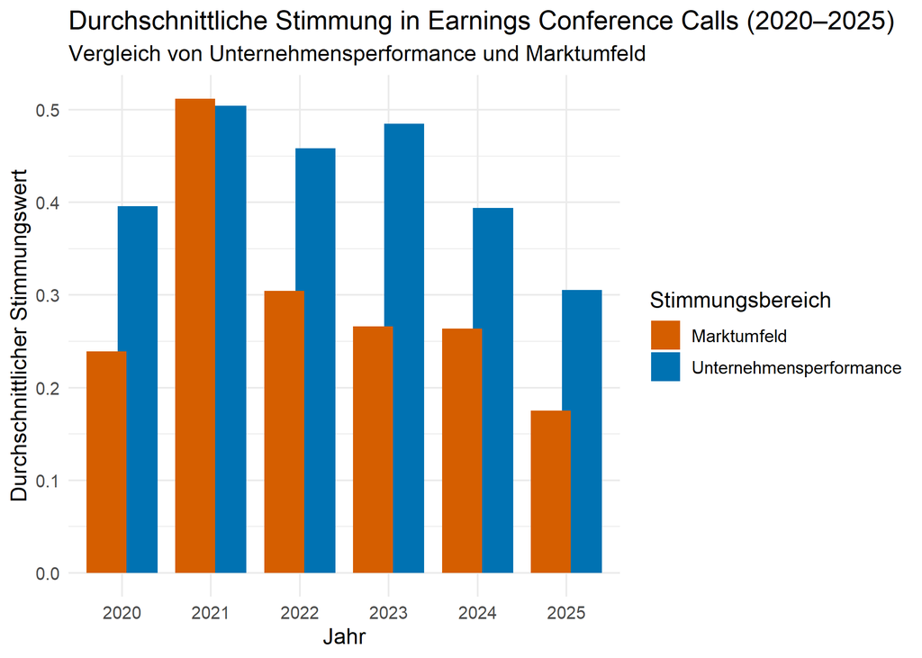

**Beschreibung der Grafik**  
Die Grafik zeigt die durchschnittlichen Stimmungswerte pro Jahr für das Marktumfeld und die Unternehmensperformance, basierend auf allen von Gemini analysierten Earnings Conference Calls im Zeitraum von 2020 bis 2025.  
Dabei wird deutlich, dass die Stimmung im Marktumfeld – bestehend aus den Faktoren Branche, Wettbewerb und externe Einflüsse – in jedem Jahr positiv ausfällt. Das Jahr 2021 stellt mit einem Wert von über 0,5 einen deutlichen Ausreißer nach oben dar, während 2025 mit einem Wert von rund 0,18 einen markanten Rückgang zeigt. Die übrigen Jahre bewegen sich auf einem stabilen Niveau zwischen 0,24 und 0,31.  
Auch die durchschnittliche Stimmung zur Unternehmensperformance fällt in jedem Jahr positiv aus. Insbesondere die Jahre 2020 bis 2024 zeigen relativ konstante und hohe Werte zwischen 0,39 und 0,50. Im Jahr 2025 hingegen ist ein klarer Rückgang auf etwa 0,30 zu beobachten.

Die Ergebnisse entsprechen insgesamt den Erwartungen und spiegeln die zentralen wirtschaftlichen und politischen Entwicklungen der vergangenen fünf Jahre auf nachvollziehbare Weise wider.

# Eventstudie

Um zu evaluieren, ob die Earnings Conference Calls tatsächlich einen Einfluss auf die Aktienkurse der einzelnen Unternehmen hatten können Sie eine sogenannte Eventstudie durchführen, welche Sie bereits in Aufgabe 1 kennen gelernt haben. Bei einer Eventstudie betrachten Sie nur die Zeit (bei uns die Tage) unmittelbar vor oder nach einem Event. In diesem Projekt ist ein Event ein Earnings Conference Call des jeweiligen Unternehmens. Sie sollen in diesem Projekt herausfinden, wie sich über alle Unternehmen hinweg die Earnings Conference Calls auf die Aktienrenditen auswirken.

13. Verbinden Sie den Datensatz über die *Stimmung der Earnings Conference Calls (sentiment.Rds)* zu den einzelnen Unternehmen mit den *abnormalen Renditen* und speichern diesen Datensatz als `gesamtdatensatz` in R ab. Sie können das RIC-Kürzel und Datum für den Join verwenden. Sollte der Earnings Conference Call an keinem Handelstag stattgefunden haben, so joinen Sie bitte mit dem darauffolgenden Handelstag.
- Für die Tage an denen ein Earnings Conference Call stattgefunden hat sollten Sie eine Variable `event` generieren, welche an dem Tag des Calls gleich 0 ist.
- Für die Tage vor dem Earnings Conference Call (Event) sollte die Variable `event` rückwärts zählen (bis zu -5). Für alle Tage nach dem Event sollte die Variable `event` fortgeführt werden (bis +5).
- Erstellen Sie eine Variable `ar_505`, welche die *abnormalen Rendite* von Tag -5 bis +5 **fortlaufend** aufsummiert
- Erstellen Sie eine Variable `car_101`, welche die kumulierte abnormale Rendite im Zeitraum -1 bis +1 um das Event beinhaltet
- Erstellen Sie weiterhin diese sechs neuen Variablen:
  - `negativ_firm` = Wenn die Unternehmensperformance als negativ eingeschätzt wird
  - `neutral_firm` = Wenn die Unternehmensperformance als neutral eingeschätzt wird
  - `positiv_firm` = Wenn die Unternehmensperformance als positiv eingeschätzt wird
  - `negativ_market` = Wenn die Marktperformance als negativ eingeschätzt wird
  - `neutral_market` = Wenn die Marktperformance als neutral eingeschätzt wird
  - `positiv_market` = Wenn die Marktperformance als positiv eingeschätzt wird
- Erstellen Sie Dummy Variablen, die 1 sind für ein bestimmtes Jahr. Bspw. eine Dummyvariable die 2020 heißt und für alle Beobachtungen im Jahr 2020 sollte diese Variable 1 sein, 0 sonst. Tun Sie dies für alle Jahre in ihrem Datensatz

*Hinweis:* Die Funktion cumsum() könnte für diese Aufgabe hilfreich sein

14. Erstellen Sie je ein Liniendiagramm für die von ihnen betrachteten Unternehmen: Eines für die Stimmung bezüglich der Unternehmensperformance und eines bezüglich der Marktperformance.

Sie sollten in ihren Grafiken die kumulierten Renditen im Zeitraum [-5,5] Tage um einen Earnings Conference Call darstellen. - Die Variable “Event” sollte die Tage vor und nach dem Earnings Conference Call enthalten ([-5,5]) und auf der x-Achse dargestellt werden - Die Variable `ar_505` sollte die durchschnittliche kumulierte abnormale Rendite für den jeweiligen Tag auf der y-Achse abtragen (für alle Unternehmen in ihrem Datensatz) - In jeder Grafik sollten Sie eine extra Linie zeichnen für Earnings Conference Calls mit einer positiven/negativen und neutralen Stimmung und deren Einfluss auf den Aktienmarkt

Beschreiben und interpretieren Sie ihre Grafik. Gehen Sie hierbei insbesondere darauf ein, welche Erwartungen Sie auf der Basis ihrer Lektüre aus Aufgabe 1 hatten und in wie weit diese Erwartungen sich erfüllt haben.

*Hinweis:* In diesen Grafiken stellen Sie nicht jedes Event (d.h. die Auswirkungen eines jeden Earnings Conference Calls) einzeln dar, sondern gesamt für alle Earnings Conference Calls.

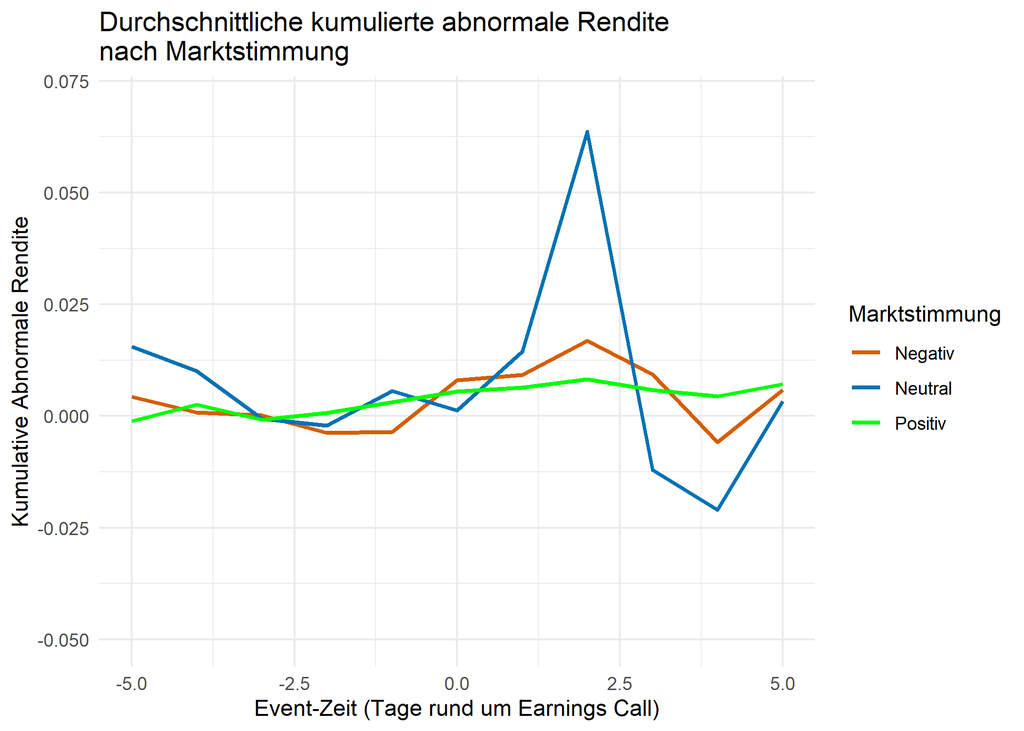

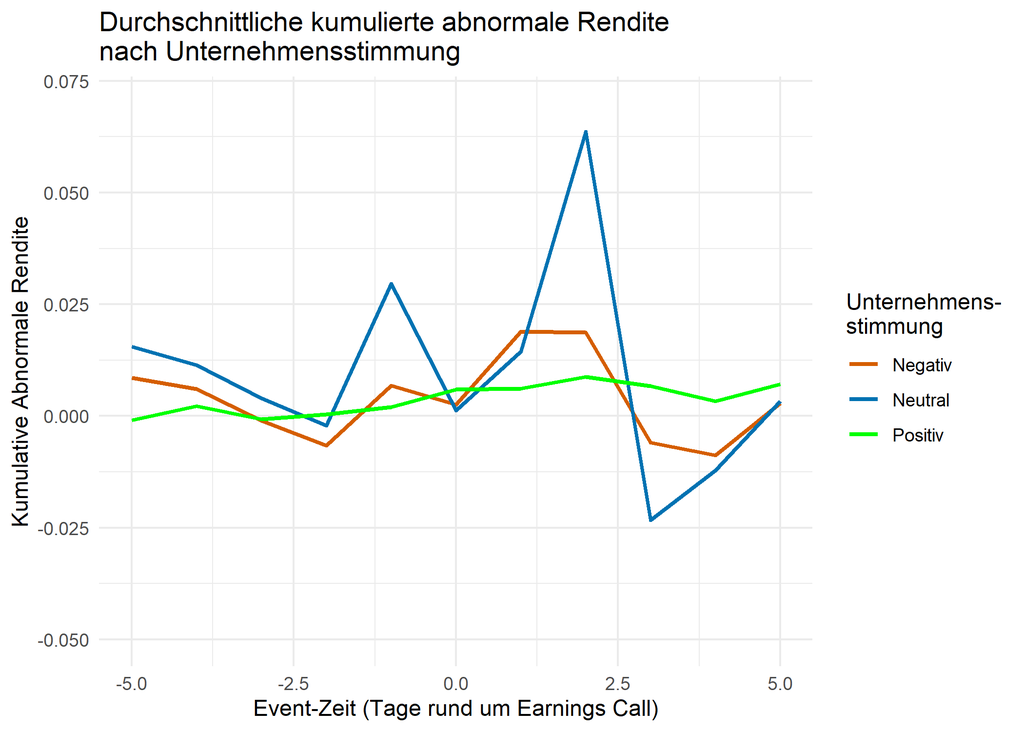

**Beschreibung der Grafik**  
In den zwei dargestellten Grafiken ist die durchschnittliche kummulierte abnormale Rendite jeweils 5 Tage vor und 5 Tage nach der Earnings Call Conference abgetragen. Die erste Grafik zeigt dabei die Entwicklungen nach der Marktstimmung und die zweite Grafik zeigt die Entwicklulngen nach der Unternehmensstimmung. In beiden Grafiken zeigt die x-Achse die Tage um den Earnings Call (-5 Tage bis +5 Tage), wobei an Tag 0 der Earnings Call stattfand. Auf der y-Achse wird die kumulative abnormale Rendite gezeigt. Die Unternehmen wurden in die Gruppen Negativ (orange), Neutral (blau) und Positiv (grün) untergliedert, was die Stimmung in den Earnings Calls jeweils für das Unternehmen und für den Markt darstellt.

Auffällig ist sowohl in Bezug auf den Markt und das Unternehmen, dass kurz vor dem Earnings Call Bewegungen der Renditen stattfinden, was bedeutet, dass entweder viel gekauft oder verkauft wird. Die Verläufe könnten darauf hindeuten, dass ein Teil der Informationen bereits vor dem Earnings Call im Markt ist, oder zumindest der Markt Erwartungen bildet, die sich in den Kursen widerspiegeln. Dies könnte auch durch Analystenberichte, Medienberichte oder Marktgerüchte geschehen. Außerdem ist auffällig, dass die kumulierte Rendite bei einer neutralen Unternehmensstimmung oder Marktstimmung am höchsten ausfällt. Dies könnte an den nicht vorhandenen Erwartungen liegen, wodurch schon ein paar wenige positive Ergebnisse aus dem Earnings Call zu positiven Kursbewegungen führen könnten.

# Regressionen

Sie haben bisher den Einfluss der Earnings Conference Calls auf die Aktienrendite der größten europäischen Unternehmen im Technologie-Sektor visuell betrachtet. Im letzten Abschnitt dieser Projektarbeit analysieren Sie ihre Daten mittels linearer Regressionen.

15. In dieser Aufgabe sollten Sie zwei Regressionen erstellen:

Regressieren Sie die kumulierten abnormalen Renditen um das Event `car_101` auf die Dummyvariablen

- `negativ_firm` und `negativ_market` in der ersten Regression und
- `positiv_firm` und `positiv_market` in der zweiten Regression.

Diese Dummyvariablen geben die Stimmung in den Earnings-Conference Calls wieder.

Beschreibung und interpretieren Sie ihre Regressionsergebnisse und gehen Sie dabei auch auf folgende Fragen ein:

- Was ist die Vergleichsgruppe in den beiden Regressionen?
- Was sind die Voraussetzungen für eine kausale Interpretation der Koeffizienten. Sind diese ihrer Meinung nach gegeben?

|  | Negative Stimmung | Positive Stimmung |
| --- | --- | --- |
| Konstante | 0.008* | -0.032* |
|  | (0.004) | (0.018) |
| Negative Unternehmensstimmung | -0.051** |  |
|  | (0.022) |  |
| Negative Marktstimmung | 0.006 |  |
|  | (0.012) |  |
| Positive Unternehmensstimmung |  | 0.049** |
|  |  | (0.021) |
| Positive Marktstimmung |  | -0.010 |
|  |  | (0.012) |
| Num.Obs. | 403 | 403 |
| R2 | 0.014 | 0.014 |
| R2 Adj. | 0.010 | 0.009 |

* p < 0.1, ** p < 0.05, *** p < 0.01

**Was ist die Vergleichsgruppe in den Regressionen?**  
Die Vergleichsgruppe in der ersten Regression besteht aus allen Earnings Calls, in denen keine negative Unternehmens- oder Marktstimmung festgestellt wurde – d. h. die Stimmungen waren entweder neutral oder positiv.  
In der zweiten Regression bilden jene Earnings Calls die Vergleichsgruppe, in denen keine positive Unternehmens- oder Marktstimmung vorlag – also Fälle mit neutraler oder negativer Stimmung.

16. In ihrer deskriptiven Analyse haben Sie bereits gesehen, dass die Unternehmen, die Sie in diesem Projekt betrachten, alle unterschiedlich groß sind. Weiterhin haben Sie gesehen, dass es ein unterschiedliches Stimmungsbild in den Calls über die einzelnen Jahre hinweg gibt. Dafür möchten Sie in ihren Regressionen nun kontrollieren.
    1. Regressieren Sie die `car_101` auf die Variablen *negativ_firm* und *negativ_market* und kontrollieren Sie auf die Größe des jeweiligen Unternehmens, indem Sie die Variable *Total_Assets* in ihre Regression aufnehmen
    2. Fügen Sie in einer zweiten Analyse zusätzlich zu den Variablen aus der 1. Regression auch noch Dummyvariablen für die Jahre in dem das Event stattgefunden hat ihrer Regression hinzu.
    3. Führen Sie die Regressionen aus 1. und 2. auch für die Variablen *positiv_firm* und *positiv_market* anstatt *negativ_firm* und *negativ_market* durch, sodass Sie am Ende 4 Regressionen haben

Beschreiben und interpretieren Sie ihre Ergebnisse im Hinblick auf die Größe der Koeffizienten und deren Signifikanz. Gehen Sie insbesondere auf folgende Fragen ein:

- Warum sollte ihre Regression nicht fünf Dummyvariablen, je eine für jedes Jahr, sondern nur vier beinhalten?
- Verändert sich durch die Dummyvariablen der Koeffizient von *negativ_firm* und *negativ_market* bzw. *positiv_firm* und *positiv_market*?
- Hätten Sie eine Veränderung des Koeffizienten von *negativ_firm*, *negativ_market*, *positiv_firm* oder *positiv_market* erwartet? Begründen Sie ihre Antwort mit ihren deskriptiven Analysen.

|  | Negativ ohne Jahr-Dummies | Negativ mit Jahr-Dummies | Positiv ohne Jahr-Dummies | Positiv mit Jahr-Dummies |
| --- | --- | --- | --- | --- |
| Konstante | 0.009* | 0.064 | -0.035* | 0.021 |
|  | (0.005) | (0.072) | (0.020) | (0.075) |
| Negative Unternehmensstimmung | -0.045** | -0.043* |  |  |
|  | (0.023) | (0.023) |  |  |
| Negative Marktstimmung | -0.004 | -0.004 |  |  |
|  | (0.012) | (0.013) |  |  |
| Positive Unternehmensstimmung |  |  | 0.044** | 0.043* |
|  |  |  | (0.022) | (0.022) |
| Positive Marktstimmung |  |  | 0.000 | 0.000 |
|  |  |  | (0.012) | (0.013) |
| Bilanzsumme (Assets) | 0.000 | 0.000 | 0.000 | 0.000 |
|  | (0.000) | (0.000) | (0.000) | (0.000) |
| Jahr 2020 |  | -0.048 |  | -0.049 |
|  |  | (0.073) |  | (0.073) |
| Jahr 2021 |  | -0.059 |  | -0.059 |
|  |  | (0.073) |  | (0.073) |
| Jahr 2022 |  | -0.050 |  | -0.050 |
|  |  | (0.073) |  | (0.073) |
| Jahr 2023 |  | -0.053 |  | -0.053 |
|  |  | (0.073) |  | (0.073) |
| Jahr 2024 |  | -0.064 |  | -0.065 |
|  |  | (0.073) |  | (0.073) |
| Num.Obs. | 367 | 367 | 367 | 367 |
| R2 | 0.016 | 0.024 | 0.014 | 0.022 |
| R2 Adj. | 0.008 | 0.002 | 0.006 | 0.001 |

* p < 0.1, ** p < 0.05, *** p < 0.01

**Warum sollte ihre Regression nicht fünf Dummyvariablen, je eine für jedes Jahr, sondern nur vier beinhalten?**  
Wenn man für alle fünf Jahre Dummyvariablen einfügen würde und gleichzeitig eine Konstante (Intercept) in der Regression hat, entsteht Multikollinearität. Die fünfte Jahresvariable wäre perfekt vorhersehbar aus den anderen und der Konstante. Deshalb muss ein Jahr ausgelassen werden, damit man alle anderen Jahre im Vergleich zu dieser Referenzkategorie interpretieren kann.

**Hätten Sie eine Veränderung des Koeffizienten von *negativ_firm*, *negativ_market*, *positiv_firm* oder *positiv_market* erwartet? Begründen Sie ihre Antwort mit ihren deskriptiven Analysen.**  
Nein, eine Veränderung der Koeffizienten war nicht zu erwarten. Die Regressionen zeigen, dass die Unternehmensstimmung – die in der deskriptiven Statistik recht klar positiv oder negativ ausfällt – signifikante Unterschiede in den Renditen bewirkt. Die Marktstimmung ist dagegen diffuser und hat erwartungsgemäß keinen signifikanten Einfluss, was mit der höheren Streuung und der negativen Einschätzung externer Faktoren zusammenhängt.

17. Zum Abschluss sollten Sie dazu Stellung beziehen, in wie weit die Erkenntnisse aus diesem Projekt für eine Handelsstrategie genutzt werden könnten. Konkret sollten Sie erläutern ob es sinnvoll ist eine Unternehmensaktie bei einem negativem Sentiment im Earnings Conference Call automatisiert zu verkaufen.

Beziehen Sie sich in ihrer Argumentation insbesondere auf:

- Zeitliche Aspekte (Wann reagiert der Markt vs. wann liegt das Sentiment vor?)
- Methodische Limitationen Ihrer Event Study
- Unsicherheiten bei der LLM-Sentiment-Analyse

Begründen Sie jeden Kritikpunkt konkret mit Bezug auf Ihre Projektarbeit und schließen Sie mit einer realistischen Einschätzung ab: Wofür könnten Ihre Ergebnisse trotz dieser Limitationen in der Praxis dennoch wertvoll sein?

In unserem Projekt haben wir untersucht, ob man Aktien automatisch verkaufen sollte, sobald das Sentiment aus einem Earnings Call negativ ist. Dabei fällt zuerst auf: Die Kurse bewegen sich oft schon am Call-Tag oder sogar noch während des Calls – unser Sentiment-Score dagegen steht in der Regel erst Stunden bis Tage später fertig zur Verfügung, weil erst das Transkript verarbeitet und an das LLM geschickt werden muss. Für einen schnellen Trade ist das einfach zu spät.

Außerdem haben wir die abnormalen Renditen mit einem recht simplen Marktmodell auf Basis des Euro Stoxx 600 berechnet. Das heißt, wir haben weder makroökonomische Schocks noch Unterschiede zwischen großen und kleinen oder hoch- und geringliquiden Firmen berücksichtigt. Solche Vereinfachungen können dazu führen, dass die tatsächliche Wirkung des Call-Sentiments überschätzt oder unterschätzt wird. Und wenn ein Call zeitgleich mit einer großen M&A-Ankündigung oder Quartalszahl stattfindet, lässt sich gar nicht mehr sauber sagen, was genau den Kurs bewegt hat.

Die Sentiment-Analyse mit einem LLM wie Google Gemini bringt zusätzliche Unsicherheit. Schon minimale Änderungen im Prompt oder in der Reihenfolge der Fragen liefern teils sehr unterschiedliche Scores. Und weil das Modell keine Begründungen ausgibt, ist oft unklar, warum ein Call als „negativ“ eingestuft wurde. Finanzjargon versteht das LLM auch nicht immer korrekt – Begriffe wie „beat‑and‑raise“ oder „cautious outlook“ landen schnell mal in der falschen Kategorie.

Deshalb wäre ein automatischer Verkaufsalgorithmus, der nur auf dem negativen LLM-Sentiment basiert, zurzeit stark risikobehaftet und operativ zu langsam. Viel sinnvoller ist es, das negative Sentiment als Warnsignal zu sehen: Es zeigt, welche Calls man genauer von Hand anschauen sollte. In einem hybriden Modell kann es dann zusammen mit anderen Indikatoren (Analystenkommentaren, Volumensignalen, Volatilität) ein nützliches Feature sein – aber nie allein die Entscheidung für einen Verkauf treffen.

# Zusatzaufgabe

In Aufgabe 6 berechnen Sie die *abnormalen Renditen* der einzelnen von ihnen betrachteten Unternehmen. Nun könnte es allerdings sein, dass es nicht ausreicht den Marktindex einfach von der Aktienrendite abzuziehen um für die erwartete Performance der Aktie zu kontrollieren. Potentiell wäre es besser für die durchschnittliche Performance der Aktie zu kontrollieren in der keine Events stattfinden.

Sie können eine solche durchschnittliche Performance schätzen. Dazu sollten Sie eine Schätzperiode *vor* dem Event definieren. Diese Periode sollen Sie auf 120 bis 10 Handelstage vor dem Event festlegen. Die durchschnittliche Rendite der Einzelaktie sollten Sie in dieser Periode auf die Marktrendite regressieren. Dieses Modell wird `Risk-adjusted returns model` in Huntington-Klein (2021) genannt:

$$\begin{equation}
\hat{Rendite}_{i,t} = \alpha + \beta Rendite_{m,t}
\end{equation}$$

Anschließend nutzen Sie die vorhergesagten Werte und ziehen diese in der Eventphase von der Rendite der Einzelaktie ab.

18. Erstellen Sie die kumulierten abnormalen Renditen im Zeitraum -5 bis +5 mit Hilfe ihres Risk-adjusted returns model neu (und nennen diese `mar_505`). Erstellen Sie die kumulierten abnormalen Renditen im Zeitraum -1 bis +1 um das Event mit Hilfe ihres Risk-adjusted returns model neu (und nennen die Variable `cmar_101`) und vergleichen die Werte in einer geeigneten Grafik mit den Ergebnissen aus dem market-adjusted returns model (`car_101`).
- Gibt es hier große Unterschiede?
- Warum gibt es diese Unterschiede, oder warum sehen Sie nur geringe Unterschiede?

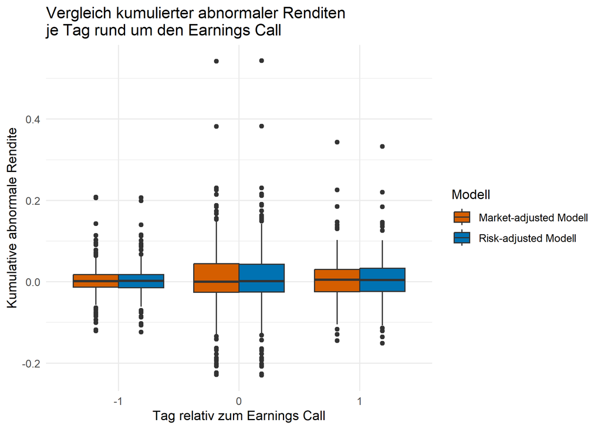

**Beschreibung der Grafik**  
In der Grafik sind die kummulierten abnormalen Renditen jeweils am Tag der ECC und jeweils am Tag davor und danach dargestellt. Die Renditen wurden einmal nach dem Market-adjustet Modell und nach dem Risk-adjusted Modell berechnet. Die Boxplots stellen hier die Verteilung der Renditen dar.

**Interpretation der Grafik**  
In dieser Analyse wurde überprüft, ob das einfache Market-adjusted Returns-Modell zur Berechnung abnormaler Renditen um Earnings Conference Calls (ECC) vergleichbare Ergebnisse liefert wie das differenziertere Risk-adjusted Returns-Modell. Während beim Market-adjusted-Modell die Marktrendite direkt von der Aktienrendite subtrahiert wird, basiert das Risk-adjusted-Modell auf einer Regressionsschätzung individueller Renditeverläufe vor dem Eventzeitraum. Dabei wird die erwartete Aktienrendite als lineare Funktion der Marktrendite modelliert.  
Ein Vergleich der cmar_101 mit den zuvor berechneten car_101 (basierend auf dem einfachen Modell) zeigt, dass sich beide Ansätze im Ergebnis kaum unterscheiden. Wie man in der Grafik erkennt, ergeben sich nur sehr geringe oder gar keine Unterschiede in Lage und Streuung der Werte. Diese Beobachtung lässt sich plausibel damit erklären, dass viele der analysierten Unternehmen – allesamt große europäische Technologiekonzerne – eine hohe Korrelation mit dem Gesamtmarkt aufweisen. Die im Risk-adjusted-Modell geschätzten β-Koeffizienten dürften somit bei vielen Unternehmen nahe 1 liegen, während die Intercepte (α) tendenziell gering sind. In einem solchen Fall nähert sich das Risk-adjusted-Modell stark dem einfachen Market-adjusted-Modell an.  
Es lässt sich also festhalten, dass der Mehraufwand des Risk-adjusted-Modells in diesem spezifischen Datensatz keinen signifikanten zusätzlichen Informationsgewinn liefert. Für Unternehmen mit stabiler Marktkopplung scheint das einfachere Modell somit ausreichend geeignet zu sein. In Szenarien mit höherer Volatilität, geringer Marktkorrelation oder strukturellen Besonderheiten wäre das Risk-adjusted-Modell hingegen potenziell informativer.

19. Erstellen Sie die Grafik von Aufgabe 12 neu.

Beschreiben und interpretieren Sie ihre Grafik. Gehen Sie auch auf folgende Fragen ein:

- Könnte es zu Problemen führen, wenn in der Schätzperiode vor dem Event ein weiterer Earnings-Conference Call enthalten ist?
  - Warum könnte dies ein Problem sein, oder warum nicht?

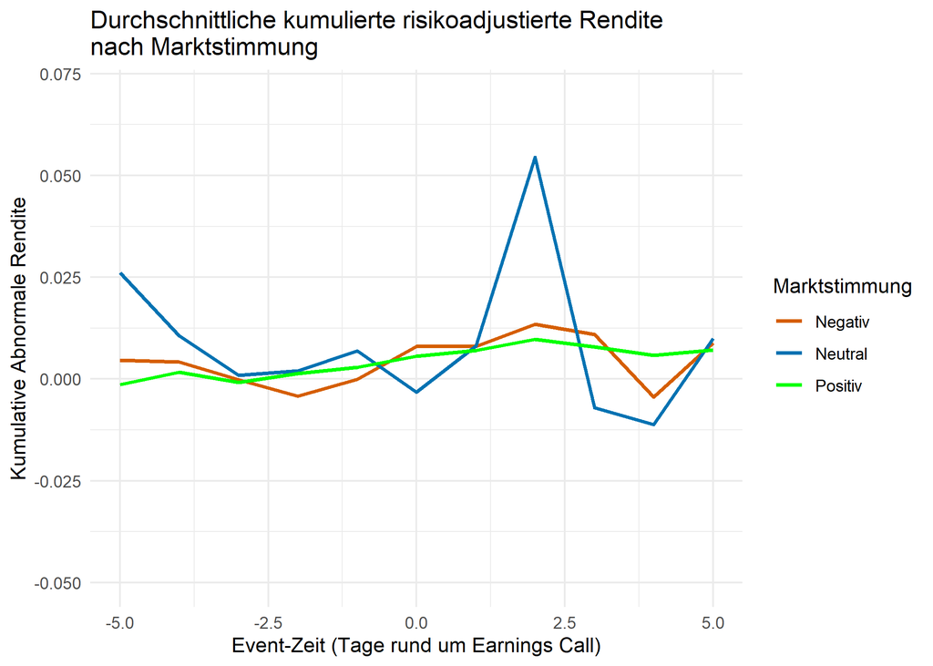

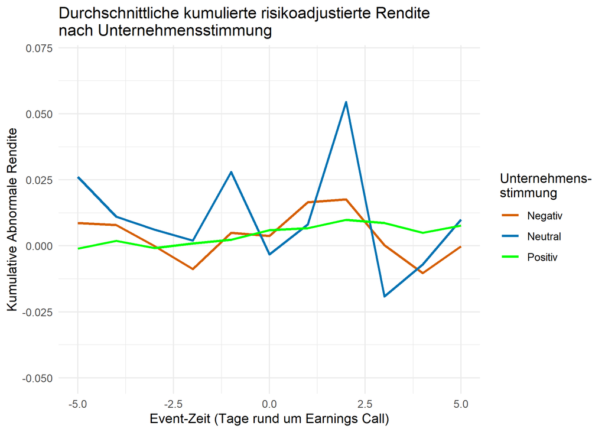

**Beschreibung der Grafik**  
Die Grafiken zeigen die durchschnittliche kumulierte abnormale Rendite rund um den Earnings Conference Call für den Zeitraum von fünf Handelstagen vor bis fünf Handelstage nach dem Event (−5 bis +5). Dabei wird zwischen der Marktstimmung und der Unternehmensstimmung differenziert. Grundlage dieser Darstellung ist das Risk-adjusted Returns-Modell, bei dem die erwartete Rendite mithilfe einer Regression in einer Schätzperiode (−120 bis −10 Handelstage vor dem Event) individuell je Unternehmen berechnet wurde. Die Stimmungen wurden wieder mithilfe der unterschiedlichen Linien dargestellt.  
Insgesamt betrachtet ist ein ähnliches Muster wie in Aufgabe 14 zu sehen. Es gibt also so gut wie keine Unterschiede zum Market-adjusted-Modell.

**Könnte es zu Problemen führen, wenn in der Schätzperiode vor dem Event ein weiterer Earnings-Conference Call enthalten ist?**  
Ja, dies kann zu erheblichen Verzerrungen führen, da die Schätzperiode eigentlich eine “normale” Zeit repräsentieren soll – also eine Phase ohne außergewöhnliche Ereignisse. Ist in diesem Zeitraum ein weiterer Earnings Conference Call enthalten, besteht die Gefahr, dass dieser bereits abnormal hohe oder niedrige Renditen verursacht, die fälschlicherweise als „normal“ modelliert werden. Dadurch könnten die geschätzten erwarteten Renditen verzerrt sein und somit auch die daraus abgeleiteten abnormalen Renditen.

**Warum ist das ein Problem?**  
Ein verzerrtes α oder β aus der Regressionsschätzung führt zu einer fehlerhaften Berechnung der erwarteten Renditen, was wiederum die Interpretation der abnormalen Renditen im Eventfenster verfälscht. Besonders kritisch ist dies, wenn ECCs sehr häufig stattfinden (z.B. bei Quartalsdaten), da sich die Schätzfenster dann teilweise überschneiden können. Um dem entgegenzuwirken, sollte idealerweise geprüft werden, ob innerhalb der Schätzperiode frühere Events liegen und diese ggf. aus der Regression ausgeschlossen werden.

20. Lesen Sie das Kapitel [“Fixed Effects” in Huntington-Klein (2021)](https://theeffectbook.net/ch-FixedEffects.html#how-does-it-work), speziell Kapitel 16.1
21. Regressieren Sie die `cmar_101` auf die Variablen *negativ_firm* und *negativ_market* und kontrollieren Sie auf die Größe des jeweiligen Unternehmens, indem Sie die Variable *Total_Assets* in ihre Regression aufnehmen. Kontrollieren Sie weiterhin auf das Jahr in dem das Event stattgefunden hat. Fügen Sie weiterhin der Regression Firmen-Fixe Effekte hinzu.

Beschreiben und interpretieren Sie ihre Ergebnisse.

Gehen Sie zusätzlich auf die folgenden Frage ein:

- Was sind Firmen-Fixe Effekte und warum könnten diese für ihre Regression sinnvoll sein?

*Hinweis:* Mit dem [Paket `fixest`](https://cran.r-project.org/web/packages/fixest/vignettes/fixest_walkthrough.html) und der Funktion feols() können Sie einfach ihren Regressionen fixe Effekte hinzufügen

|  | (1) |
| --- | --- |
| Negative Unternehmensstimmung | -0.032 |
|  | (0.022) |
| Negative Marktstimmung | -0.003 |
|  | (0.025) |
| Bilanzsumme (Assets) | 0.000 |
|  | (0.000) |
| Jahr 2020 | -0.032*** |
|  | (0.011) |
| Jahr 2021 | -0.046*** |
|  | (0.007) |
| Jahr 2022 | -0.039*** |
|  | (0.005) |
| Jahr 2023 | -0.038*** |
|  | (0.009) |
| Jahr 2024 | -0.054*** |
|  | (0.007) |
| Num.Obs. | 365 |
| R2 | 0.092 |
| R2 Adj. | -0.007 |
| R2 Within | 0.018 |
| R2 Within Adj. | -0.006 |
| Std.Errors | by: RIC |
| FE: RIC | X |

* p < 0.1, ** p < 0.05, *** p < 0.01

**Beschreibung**  
In dieser Regression wird die kumulierte risikoadjustierte Rendite (cmar_101) im Zeitraum von einem Tag vor bis einem Tag nach dem Earnings Call auf verschiedene Einflussfaktoren geschätzt: negative Unternehmensstimmung, negative Marktstimmung, Bilanzsumme (Assets) sowie Jahresdummies für 2020 bis 2024. Zudem werden firmenspezifische fixe Effekte berücksichtigt.  
Es zeigt sich, dass weder die Unternehmens- noch die Marktstimmung signifikant auf die Rendite wirken. Auch die Unternehmensgröße hat keinen erkennbaren Einfluss. Die Jahresdummies hingegen sind allesamt statistisch signifikant negativ auf dem 1%-Niveau: Das Jahr 2020 ist mit einer Rendite von -3,2% verbunden, 2021 mit -4,6%, 2022 mit -3,9%, 2023 mit -3,8% und 2024 mit -5,4%.

**Interpretation**  
Die signifikant negativen Effekte der Jahre 2020–2024 im Vergleich zum Basisjahr 2025 könnten durch makroökonomische Schocks erklärt werden – insbesondere die COVID-19-Pandemie, geopolitische Spannungen wie der Ukraine-Krieg sowie geldpolitische Straffungen aufgrund der globalen Inflation. Die ausbleibende Signifikanz der Stimmungsvariablen deutet darauf hin, dass die Stimmung entweder bereits in den Kursen antizipiert war oder als wenig kursrelevant wahrgenommen wurde.

**Was sind Firmen-Fixe Effekte und warum könnten diese für ihre Regression sinnvoll sein?**  
Firmen-Fixe Effekte kontrollieren für zeitlich konstante, unternehmensspezifische Merkmale wie Branche, Geschäftsmodell, Management oder Risikoexposition. Sie ermöglichen eine isolierte Betrachtung der zeitlich variablen Effekte, indem Unterschiede zwischen Firmen herausgerechnet werden. Dadurch wird die Schätzung verzerrungsfreier und kausal interpretierbar.

# Literatur

- Kapitel Event Studies im Buch [The Effect Book: Event Studies](https://theeffectbook.net/ch-EventStudies.html)
- Kapitel Fixe Effekte im Buch [The Effect Book: Event Studies](https://theeffectbook.net/ch-FixedEffects.html)
- [Paket `fixest`](https://cran.r-project.org/web/packages/fixest/vignettes/fixest_walkthrough.html)

# Anhang

## Prompt Arten

Prompt-Arten unterscheiden sich in der Anzahl der Beispiele, die Sie dem KI-Modell geben:

**Zero-Shot Prompt**

- Keine Beispiele gegeben
- Nur die Aufgabe wird beschrieben
- Beispiel: “Übersetze ins Englische: Guten Morgen”

**One-Shot Prompt**

- Ein einziges Beispiel wird gezeigt
- Das Modell lernt aus diesem einen Beispiel
- Beispiel: “Übersetze ins Englische:

Guten Tag → Good day Guten Morgen → ?”

**Few-Shot Prompt**

- Mehrere Beispiele werden gegeben (typisch 2-5)
- Das Modell kann aus mehreren Mustern lernen
- Beispiel: “Übersetze ins Englische:

Guten Tag → Good day Auf Wiedersehen → Goodbye Danke → Thank you Guten Morgen → ?”